# Credit Card Approval Prediction

### Description:

### Credit Approval Prediction Domain Background:

### History:

According to historian Jonathan Kenoyer, The concept of using a valueless instrument to represent banking transactions dates back 5000 years. The charga-plate, developed in 1928 was an early predecessor of the credit card. The first universal credit card was introduced by Diners Club, Inc., in 1950. Presently cooperating merchants of the credit card issuer throughout the world would pay service charge in range of 4-7% of total billings.

When you apply for a credit card, you may be asked to disclose your income as part of the application. The card issuer will likely look at your overall income relative to your debt also known as debt-to-income ratio, To make sure the company doesn’t offer you more credit than they think you can reasonably payback

There are many more factors that are considered while issuing a credit card . Here I am going to predict whether a credit card can be approved or not.

## Applications:

This project is predicting the approval of a credit card. And it will help the credit card issuers whether to approve a credit card or not.

## Problem Statement:

The main aim of my project is to predict the credit card approval. For doing this I selected the dataset from UCI (https://archive.ics.uci.edu/ml/datasets/Credit+Approval). So my goal is to predict the credit card approvals. Here I am using classification models to find the accuracy of each model and select the best model with high accuracy to predict the approvals. Here the input parameters are training data that we took and the output will be whether to approve the credit card or not.

## Dataset Information:

This file concerns credit card applications. All attribute names and values have been changed to meaningless symbols to protect confidentiality of the data. This dataset is interesting because there is a good mixture of attributes – Categorical, integer and real valued attributes. There are also few missing values. On a total there are 15 attributes. The total number of instances in the datasets is 690. The characteristics of the datset are multivariate. Here there are mainly two classes: + (approving credit card) and – (not approving credit card). There are 307 +’s and 383 –‘s which are closely balanced. For the best result we will split the data into training set and testing set. On a whole we will assign 70% of the data to training set and 30% of the data to testing set.

## Attributes:

A1: b, a.

A2: continuous.

A3: continuous.

A4: u, y, l, t.

A5: g, p, gg.

A6: c, d, cc, i, j, k, m, r, q, w, x, e, aa, ff.

A7: v, h, bb, j, n, z, dd, ff, o.

A8: continuous. A9: t, f.

A10: t, f.

A11: continuous.

A12: t, f.

A13: g, p, s.

A14: continuous.

A15: continuous.

A16: +,- (class attribute)

### Importing Packages

```python
import numpy as np
import pandas as pd
import matplotlib.pyplot as plt
import seaborn as sns
import warnings
warnings.simplefilter("ignore")
```

### Solution Statement:

Here, I am trying to predict the credit approval from the selected dataset for predicting the credit card approval we will use the different classification models. Then we will find the accuracy score for each model. I explore the dataset by using read_csv and for visualization which helps me to better understand the solution, I used matplotlib.pyplot.

### Reading the Dataset

```python
df=pd.read_csv('CC_data.csv')
```

### Pre-processing:

The first task is to read the data and perform visualizations on it to get some insights about the data after. Reading the data, clean the data that is removing the unwanted data or replacing null values with some constant values or removing duplicates. After data exploration I split the data into training and testing sets. After splitting the data we will apply classifying models and then predict the accuracy score for the selected model.

```python
df.head()
```

|  | Male | Age | Debt | Married | BankCustomer | EducationLevel | Ethnicity | YearsEmployed | PriorDefault | Employed | CreditScore | DriversLicense | Citizen | ZipCode | Income | Approved |
| --- | --- | --- | --- | --- | --- | --- | --- | --- | --- | --- | --- | --- | --- | --- | --- | --- |
| 0 | b | 30.83 | 0.000 | u | g | w | v | 1.25 | t | t | 1 | f | g | 202 | 0 | + |
| 1 | a | 58.67 | 4.460 | u | g | q | h | 3.04 | t | t | 6 | f | g | 43 | 560 | + |
| 2 | a | 24.5 | 0.500 | u | g | q | h | 1.50 | t | f | 0 | f | g | 280 | 824 | + |
| 3 | b | 27.83 | 1.540 | u | g | w | v | 3.75 | t | t | 5 | t | g | 100 | 3 | + |
| 4 | b | 20.17 | 5.625 | u | g | w | v | 1.71 | t | f | 0 | f | s | 120 | 0 | + |

```python
df.shape
```

```
(690, 16)
```

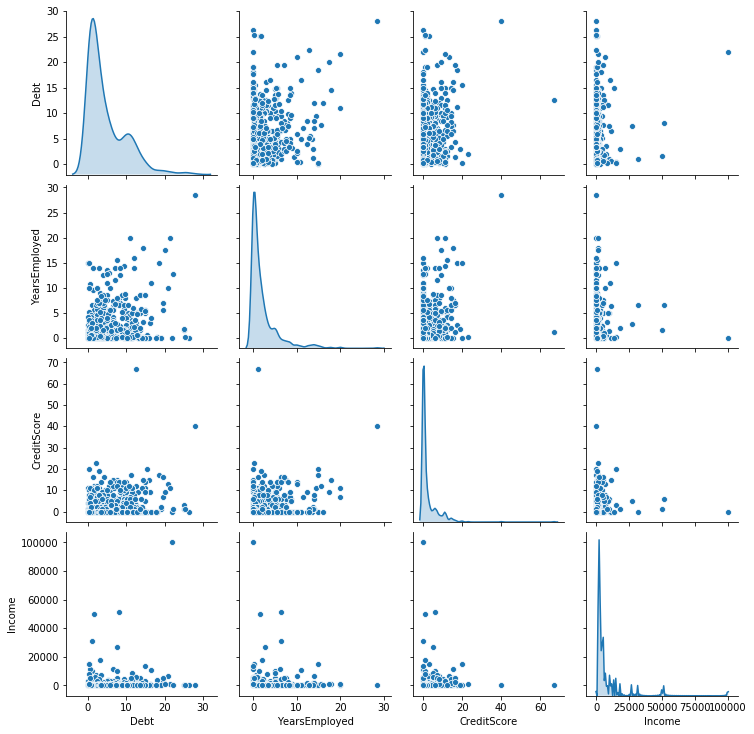

```python
sns.pairplot(df,palette="husl8",diag_kind='kde')
```

```python
df.columns
```

```
Index(['Male', 'Age', 'Debt', 'Married', 'BankCustomer', 'EducationLevel',
       'Ethnicity', 'YearsEmployed', 'PriorDefault', 'Employed', 'CreditScore',
       'DriversLicense', 'Citizen', 'ZipCode', 'Income', 'Approved'],
      dtype='object')
```

###### The Missing values are denoted by the '?' operator. So here, we are finding out the missing values in the Dataframe and replacing them with 'NaN'

```python
df=df.replace('?',np.NaN)
```

###### Checking how many null values are there in each column

```python
df.isnull().sum()
```

```
Male              12
Age               12
Debt               0
Married            6
BankCustomer       6
EducationLevel     9
Ethnicity          9
YearsEmployed      0
PriorDefault       0
Employed           0
CreditScore        0
DriversLicense     0
Citizen            0
ZipCode           13
Income             0
Approved           0
dtype: int64
```

```python
df['Male'].fillna('b',inplace=True)
df['Married'].fillna('m',inplace=True)
df['BankCustomer'].fillna('g',inplace=True)
df['Ethnicity'].fillna('v',inplace=True)
df['EducationLevel'].fillna('w',inplace=True)
```

###### Converting all the object type columns into String type columns

```python
df['Male']=df['Male'].astype('str')
df['Age']=df['Age'].astype('float')
df['Married']=df['Married'].astype('str')
df['BankCustomer']=df['BankCustomer'].astype('str')
df['Ethnicity']=df['Ethnicity'].astype('str')
df['EducationLevel']=df['EducationLevel'].astype('str')
df['ZipCode']=df['ZipCode'].astype('str')
```

```python
df.fillna(df['Age'].mean(),inplace=True)
df['Age']=df['Age'].astype('str')
```

###### Checking if there any null values exist

```python
df.isnull().sum()
```

```
Male              0
Age               0
Debt              0
Married           0
BankCustomer      0
EducationLevel    0
Ethnicity         0
YearsEmployed     0
PriorDefault      0
Employed          0
CreditScore       0
DriversLicense    0
Citizen           0
ZipCode           0
Income            0
Approved          0
dtype: int64
```

###### Checking how many unique values are contained by each coulumn

```python
df.nunique()
```

```
Male                2
Age               350
Debt              215
Married             4
BankCustomer        3
EducationLevel     14
Ethnicity           9
YearsEmployed     132
PriorDefault        2
Employed            2
CreditScore        23
DriversLicense      2
Citizen             3
ZipCode           171
Income            240
Approved            2
dtype: int64
```

```python
df
```

|  | Male | Age | Debt | Married | BankCustomer | EducationLevel | Ethnicity | YearsEmployed | PriorDefault | Employed | CreditScore | DriversLicense | Citizen | ZipCode | Income | Approved |
| --- | --- | --- | --- | --- | --- | --- | --- | --- | --- | --- | --- | --- | --- | --- | --- | --- |
| 0 | b | 30.83 | 0.000 | u | g | w | v | 1.250 | t | t | 1 | f | g | 202 | 0 | + |
| 1 | a | 58.67 | 4.460 | u | g | q | h | 3.040 | t | t | 6 | f | g | 43 | 560 | + |
| 2 | a | 24.5 | 0.500 | u | g | q | h | 1.500 | t | f | 0 | f | g | 280 | 824 | + |
| 3 | b | 27.83 | 1.540 | u | g | w | v | 3.750 | t | t | 5 | t | g | 100 | 3 | + |
| 4 | b | 20.17 | 5.625 | u | g | w | v | 1.710 | t | f | 0 | f | s | 120 | 0 | + |
| 5 | b | 32.08 | 4.000 | u | g | m | v | 2.500 | t | f | 0 | t | g | 360 | 0 | + |
| 6 | b | 33.17 | 1.040 | u | g | r | h | 6.500 | t | f | 0 | t | g | 164 | 31285 | + |
| 7 | a | 22.92 | 11.585 | u | g | cc | v | 0.040 | t | f | 0 | f | g | 80 | 1349 | + |
| 8 | b | 54.42 | 0.500 | y | p | k | h | 3.960 | t | f | 0 | f | g | 180 | 314 | + |
| 9 | b | 42.5 | 4.915 | y | p | w | v | 3.165 | t | f | 0 | t | g | 52 | 1442 | + |
| 10 | b | 22.08 | 0.830 | u | g | c | h | 2.165 | f | f | 0 | t | g | 128 | 0 | + |
| 11 | b | 29.92 | 1.835 | u | g | c | h | 4.335 | t | f | 0 | f | g | 260 | 200 | + |
| 12 | a | 38.25 | 6.000 | u | g | k | v | 1.000 | t | f | 0 | t | g | 0 | 0 | + |
| 13 | b | 48.08 | 6.040 | u | g | k | v | 0.040 | f | f | 0 | f | g | 0 | 2690 | + |
| 14 | a | 45.83 | 10.500 | u | g | q | v | 5.000 | t | t | 7 | t | g | 0 | 0 | + |
| 15 | b | 36.67 | 4.415 | y | p | k | v | 0.250 | t | t | 10 | t | g | 320 | 0 | + |
| 16 | b | 28.25 | 0.875 | u | g | m | v | 0.960 | t | t | 3 | t | g | 396 | 0 | + |
| 17 | a | 23.25 | 5.875 | u | g | q | v | 3.170 | t | t | 10 | f | g | 120 | 245 | + |
| 18 | b | 21.83 | 0.250 | u | g | d | h | 0.665 | t | f | 0 | t | g | 0 | 0 | + |
| 19 | a | 19.17 | 8.585 | u | g | cc | h | 0.750 | t | t | 7 | f | g | 96 | 0 | + |
| 20 | b | 25.0 | 11.250 | u | g | c | v | 2.500 | t | t | 17 | f | g | 200 | 1208 | + |
| 21 | b | 23.25 | 1.000 | u | g | c | v | 0.835 | t | f | 0 | f | s | 300 | 0 | + |
| 22 | a | 47.75 | 8.000 | u | g | c | v | 7.875 | t | t | 6 | t | g | 0 | 1260 | + |
| 23 | a | 27.42 | 14.500 | u | g | x | h | 3.085 | t | t | 1 | f | g | 120 | 11 | + |
| 24 | a | 41.17 | 6.500 | u | g | q | v | 0.500 | t | t | 3 | t | g | 145 | 0 | + |
| 25 | a | 15.83 | 0.585 | u | g | c | h | 1.500 | t | t | 2 | f | g | 100 | 0 | + |
| 26 | a | 47.0 | 13.000 | u | g | i | bb | 5.165 | t | t | 9 | t | g | 0 | 0 | + |
| 27 | b | 56.58 | 18.500 | u | g | d | bb | 15.000 | t | t | 17 | t | g | 0 | 0 | + |
| 28 | b | 57.42 | 8.500 | u | g | e | h | 7.000 | t | t | 3 | f | g | 0 | 0 | + |
| 29 | b | 42.08 | 1.040 | u | g | w | v | 5.000 | t | t | 6 | t | g | 500 | 10000 | + |
| ... | ... | ... | ... | ... | ... | ... | ... | ... | ... | ... | ... | ... | ... | ... | ... | ... |
| 660 | b | 22.25 | 9.000 | u | g | aa | v | 0.085 | f | f | 0 | f | g | 0 | 0 | - |
| 661 | b | 29.83 | 3.500 | u | g | c | v | 0.165 | f | f | 0 | f | g | 216 | 0 | - |
| 662 | a | 23.5 | 1.500 | u | g | w | v | 0.875 | f | f | 0 | t | g | 160 | 0 | - |
| 663 | b | 32.08 | 4.000 | y | p | cc | v | 1.500 | f | f | 0 | t | g | 120 | 0 | - |
| 664 | b | 31.08 | 1.500 | y | p | w | v | 0.040 | f | f | 0 | f | s | 160 | 0 | - |
| 665 | b | 31.83 | 0.040 | y | p | m | v | 0.040 | f | f | 0 | f | g | 0 | 0 | - |
| 666 | a | 21.75 | 11.750 | u | g | c | v | 0.250 | f | f | 0 | t | g | 180 | 0 | - |
| 667 | a | 17.92 | 0.540 | u | g | c | v | 1.750 | f | t | 1 | t | g | 80 | 5 | - |
| 668 | b | 30.33 | 0.500 | u | g | d | h | 0.085 | f | f | 0 | t | s | 252 | 0 | - |
| 669 | b | 51.83 | 2.040 | y | p | ff | ff | 1.500 | f | f | 0 | f | g | 120 | 1 | - |
| 670 | b | 47.17 | 5.835 | u | g | w | v | 5.500 | f | f | 0 | f | g | 465 | 150 | - |
| 671 | b | 25.83 | 12.835 | u | g | cc | v | 0.500 | f | f | 0 | f | g | 0 | 2 | - |
| 672 | a | 50.25 | 0.835 | u | g | aa | v | 0.500 | f | f | 0 | t | g | 240 | 117 | - |
| 673 | b | 29.5 | 2.000 | y | p | e | h | 2.000 | f | f | 0 | f | g | 256 | 17 | - |
| 674 | a | 37.33 | 2.500 | u | g | i | h | 0.210 | f | f | 0 | f | g | 260 | 246 | - |
| 675 | a | 41.58 | 1.040 | u | g | aa | v | 0.665 | f | f | 0 | f | g | 240 | 237 | - |
| 676 | a | 30.58 | 10.665 | u | g | q | h | 0.085 | f | t | 12 | t | g | 129 | 3 | - |
| 677 | b | 19.42 | 7.250 | u | g | m | v | 0.040 | f | t | 1 | f | g | 100 | 1 | - |
| 678 | a | 17.92 | 10.210 | u | g | ff | ff | 0.000 | f | f | 0 | f | g | 0 | 50 | - |
| 679 | a | 20.08 | 1.250 | u | g | c | v | 0.000 | f | f | 0 | f | g | 0 | 0 | - |
| 680 | b | 19.5 | 0.290 | u | g | k | v | 0.290 | f | f | 0 | f | g | 280 | 364 | - |
| 681 | b | 27.83 | 1.000 | y | p | d | h | 3.000 | f | f | 0 | f | g | 176 | 537 | - |
| 682 | b | 17.08 | 3.290 | u | g | i | v | 0.335 | f | f | 0 | t | g | 140 | 2 | - |
| 683 | b | 36.42 | 0.750 | y | p | d | v | 0.585 | f | f | 0 | f | g | 240 | 3 | - |
| 684 | b | 40.58 | 3.290 | u | g | m | v | 3.500 | f | f | 0 | t | s | 400 | 0 | - |
| 685 | b | 21.08 | 10.085 | y | p | e | h | 1.250 | f | f | 0 | f | g | 260 | 0 | - |
| 686 | a | 22.67 | 0.750 | u | g | c | v | 2.000 | f | t | 2 | t | g | 200 | 394 | - |
| 687 | a | 25.25 | 13.500 | y | p | ff | ff | 2.000 | f | t | 1 | t | g | 200 | 1 | - |
| 688 | b | 17.92 | 0.205 | u | g | aa | v | 0.040 | f | f | 0 | f | g | 280 | 750 | - |
| 689 | b | 35.0 | 3.375 | u | g | c | h | 8.290 | f | f | 0 | t | g | 0 | 0 | - |

690 rows × 16 columns

###### Applying LabelEncoding algorithm in order to make the dataframe compatible for predicting algorithms

```python
from sklearn.preprocessing import LabelEncoder
le=LabelEncoder()
#df['Approved']=le.fit_transform(df['Approved'])
```

```python
dff=pd.DataFrame(df.nunique())
dff
```

|  | 0 |
| --- | --- |
| Male | 2 |
| Age | 350 |
| Debt | 215 |
| Married | 4 |
| BankCustomer | 3 |
| EducationLevel | 14 |
| Ethnicity | 9 |
| YearsEmployed | 132 |
| PriorDefault | 2 |
| Employed | 2 |
| CreditScore | 23 |
| DriversLicense | 2 |
| Citizen | 3 |
| ZipCode | 171 |
| Income | 240 |
| Approved | 2 |

###### Showing how many unique values each column of the dataframe has

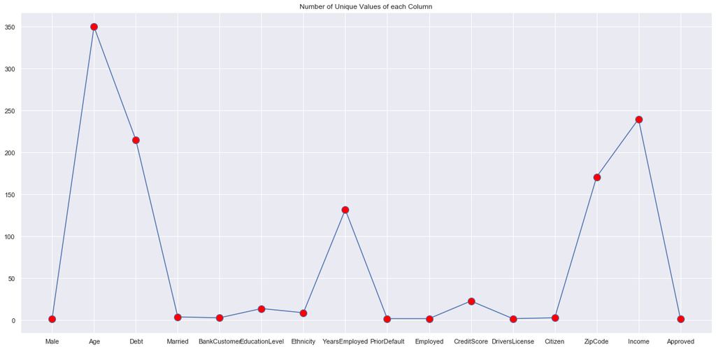

```python
sns.set()
plt.figure(figsize=(21,10))
plt.plot(dff,label=dff.columns,marker='o',markerfacecolor='red',color='b', markersize=12)
plt.title('Number of Unique Values of each Column')
plt.show()
```

```python
df.head(10)
```

|  | Male | Age | Debt | Married | BankCustomer | EducationLevel | Ethnicity | YearsEmployed | PriorDefault | Employed | CreditScore | DriversLicense | Citizen | ZipCode | Income | Approved |
| --- | --- | --- | --- | --- | --- | --- | --- | --- | --- | --- | --- | --- | --- | --- | --- | --- |
| 0 | b | 30.83 | 0.000 | u | g | w | v | 1.250 | t | t | 1 | f | g | 202 | 0 | + |
| 1 | a | 58.67 | 4.460 | u | g | q | h | 3.040 | t | t | 6 | f | g | 43 | 560 | + |
| 2 | a | 24.5 | 0.500 | u | g | q | h | 1.500 | t | f | 0 | f | g | 280 | 824 | + |
| 3 | b | 27.83 | 1.540 | u | g | w | v | 3.750 | t | t | 5 | t | g | 100 | 3 | + |
| 4 | b | 20.17 | 5.625 | u | g | w | v | 1.710 | t | f | 0 | f | s | 120 | 0 | + |
| 5 | b | 32.08 | 4.000 | u | g | m | v | 2.500 | t | f | 0 | t | g | 360 | 0 | + |
| 6 | b | 33.17 | 1.040 | u | g | r | h | 6.500 | t | f | 0 | t | g | 164 | 31285 | + |
| 7 | a | 22.92 | 11.585 | u | g | cc | v | 0.040 | t | f | 0 | f | g | 80 | 1349 | + |
| 8 | b | 54.42 | 0.500 | y | p | k | h | 3.960 | t | f | 0 | f | g | 180 | 314 | + |
| 9 | b | 42.5 | 4.915 | y | p | w | v | 3.165 | t | f | 0 | t | g | 52 | 1442 | + |

###### LabelEncoding only those which are object (str) type present here.

```python
for i in df:
    if df[i].dtype=='O':
       df[i]=le.fit_transform(df[i])
```

```python
df['Approved'].nunique()
```

```
2
```

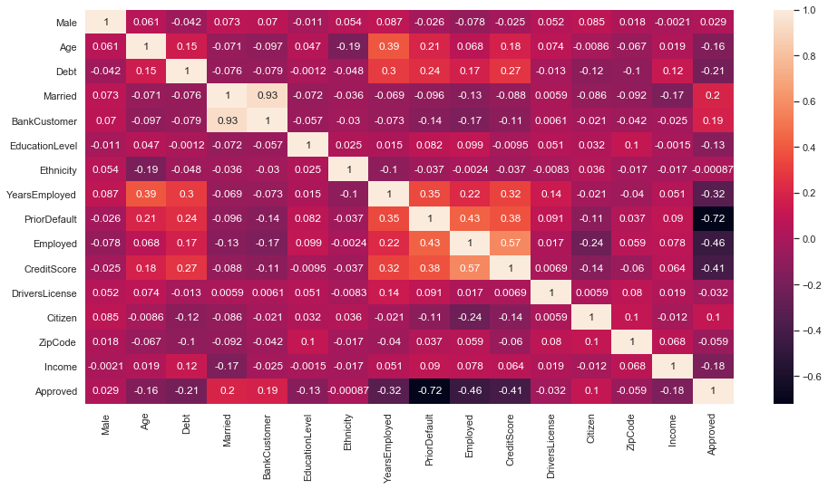

```python
plt.figure(figsize=(16,8))
sns.heatmap(df.corr(),annot=True)
```

```python
#col_names=[]
#for i in df:
#   if(df.Approved.factorize()[0] == df[i].factorize()[0]).all()==True:
#   col_names.append(i)
```

```python
#col_names
```

###### Checking the impacts of some features on the target by using Data Visualization.

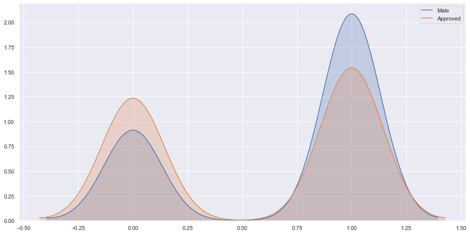

```python
plt.figure(figsize=(16,8))
m=pd.DataFrame({'Male':df['Male'],'Approved':df['Approved']})
for col in m:
    sns.kdeplot(m[col], shade=True)
```

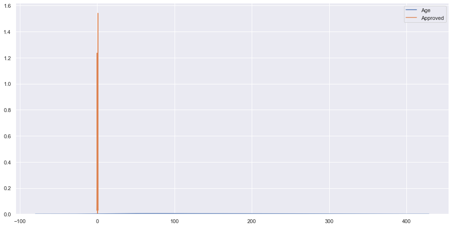

```python
plt.figure(figsize=(16,8))
a=pd.DataFrame({'Age':df['Age'],'Approved':df['Approved']})
for col in a:
    sns.kdeplot(a[col], shade=True)
```

###### It looks like there's nothing impact as such on the Approved by the Age.

```python
features=df.drop(['Approved','ZipCode','Age'],axis=1)
```

```python
labels=df['Approved']
labels
```

```
0      0
1      0
2      0
3      0
4      0
5      0
6      0
7      0
8      0
9      0
10     0
11     0
12     0
13     0
14     0
```

[output cut: 47 more lines]

```python
features.shape
```

```
(690, 13)
```

```python
labels.shape
```

```
(690,)
```

### Splitting data for training and testing

```python
from sklearn.model_selection import train_test_split
x_train, x_test, y_train, y_test = train_test_split(features,labels, test_size=0.3)
```

## Applying Algorithms

### 1. Logistic Regression:

```python
from sklearn.linear_model import LogisticRegression
lr = LogisticRegression()
lr.fit(x_train, y_train)
```

```
LogisticRegression(C=1.0, class_weight=None, dual=False, fit_intercept=True,
                   intercept_scaling=1, l1_ratio=None, max_iter=100,
                   multi_class='auto', n_jobs=None, penalty='l2',
                   random_state=None, solver='lbfgs', tol=0.0001, verbose=0,
                   warm_start=False)
```

###### Predicting...

```python
lr_pred=lr.predict(x_test)
```

```python
lr_df=pd.DataFrame({'Actual Data':y_test,'Predicted Data':lr_pred})
```

```python
lr_df
```

|  | Actual Data | Predicted Data |
| --- | --- | --- |
| 241 | 0 | 0 |
| 316 | 1 | 1 |
| 416 | 1 | 1 |
| 612 | 1 | 1 |
| 49 | 0 | 1 |
| 393 | 1 | 1 |
| 558 | 0 | 0 |
| 300 | 1 | 0 |
| 93 | 1 | 1 |
| 362 | 1 | 1 |
| 377 | 1 | 1 |
| 680 | 1 | 1 |
| 99 | 1 | 0 |
| 150 | 0 | 0 |
| 213 | 0 | 0 |
| 624 | 1 | 1 |
| 23 | 0 | 0 |
| 338 | 1 | 1 |
| 233 | 0 | 0 |
| 3 | 0 | 0 |
| 34 | 0 | 0 |
| 603 | 1 | 1 |
| 364 | 1 | 1 |
| 328 | 1 | 1 |
| 275 | 1 | 1 |
| 202 | 0 | 0 |
| 649 | 1 | 1 |
| 227 | 0 | 1 |
| 538 | 1 | 1 |
| 513 | 0 | 1 |
| ... | ... | ... |
| 379 | 1 | 1 |
| 159 | 0 | 1 |
| 37 | 0 | 0 |
| 381 | 1 | 1 |
| 631 | 1 | 1 |
| 526 | 1 | 1 |
| 242 | 0 | 0 |
| 331 | 1 | 1 |
| 47 | 0 | 0 |
| 195 | 0 | 1 |
| 487 | 1 | 1 |
| 44 | 0 | 0 |
| 297 | 1 | 1 |
| 305 | 1 | 1 |
| 544 | 1 | 1 |
| 589 | 0 | 0 |
| 623 | 1 | 1 |
| 79 | 1 | 1 |
| 539 | 1 | 0 |
| 132 | 0 | 0 |
| 566 | 0 | 0 |
| 402 | 1 | 1 |
| 441 | 1 | 1 |
| 400 | 1 | 1 |
| 67 | 0 | 0 |
| 229 | 0 | 1 |
| 342 | 1 | 1 |
| 193 | 0 | 0 |
| 685 | 1 | 1 |
| 597 | 0 | 0 |

207 rows × 2 columns

###### Actual Data Vs Predicted Data of Logistic Regression

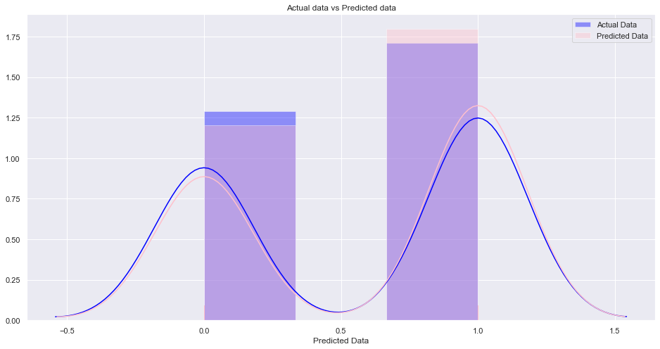

```python
sns.set_style('darkgrid')
plt.figure(figsize=(16,8))
sns.distplot(lr_df['Actual Data'],kde=True,label='Actual Data',color='blue',rug=True)
sns.distplot(lr_df['Predicted Data'],kde=True,label='Predicted Data',color='pink',rug=True)
plt.title('Actual data vs Predicted data')
plt.legend()
plt.show()
```

###### Confusion Matrix for Logistic Regression

```python
from sklearn.metrics import confusion_matrix
cmt_lr=confusion_matrix(y_test,lr_pred)
cmt_lr
```

```
array([[ 71,  18],
       [ 12, 106]], dtype=int64)
```

###### Accuracy Score for Logistic Regression

```python
from sklearn.metrics import accuracy_score
ac_lr=accuracy_score(lr_pred.round(),y_test,normalize=True)
ac_lr
```

```
0.855072463768116
```

###### Precision Score for Logistic Regression

```python
from sklearn.metrics import precision_score
pc_lr=precision_score(lr_pred.round(),y_test)
pc_lr
```

```
0.8983050847457628
```

###### Recall Score for Logistic Regression

```python
from sklearn.metrics import recall_score
rec_lr=recall_score(lr_pred.round(),y_test)
rec_lr
```

```
0.8548387096774194
```

###### f1 Score for Logistic Regression

```python
from sklearn.metrics import f1_score
f1_lr = f1_score(lr_pred.round(),y_test)
f1_lr
```

```
0.8760330578512397
```

### 2. K-NearestNeighbors Classifier

```python
from sklearn.neighbors import KNeighborsClassifier
knn=KNeighborsClassifier()
knn.fit(x_train,y_train)
```

```
KNeighborsClassifier(algorithm='auto', leaf_size=30, metric='minkowski',
                     metric_params=None, n_jobs=None, n_neighbors=5, p=2,
                     weights='uniform')
```

###### Predicting...

```python
knn_pred=knn.predict(x_test)
```

```python
knn_df=pd.DataFrame({"Actual Data":y_test,"Predicted Data":knn_pred})
```

```python
knn_df
```

|  | Actual Data | Predicted Data |
| --- | --- | --- |
| 241 | 0 | 1 |
| 316 | 1 | 0 |
| 416 | 1 | 1 |
| 612 | 1 | 0 |
| 49 | 0 | 1 |
| 393 | 1 | 1 |
| 558 | 0 | 0 |
| 300 | 1 | 1 |
| 93 | 1 | 1 |
| 362 | 1 | 1 |
| 377 | 1 | 1 |
| 680 | 1 | 1 |
| 99 | 1 | 0 |
| 150 | 0 | 0 |
| 213 | 0 | 1 |
| 624 | 1 | 1 |
| 23 | 0 | 1 |
| 338 | 1 | 1 |
| 233 | 0 | 0 |
| 3 | 0 | 0 |
| 34 | 0 | 0 |
| 603 | 1 | 1 |
| 364 | 1 | 0 |
| 328 | 1 | 1 |
| 275 | 1 | 1 |
| 202 | 0 | 0 |
| 649 | 1 | 0 |
| 227 | 0 | 1 |
| 538 | 1 | 1 |
| 513 | 0 | 1 |
| ... | ... | ... |
| 379 | 1 | 1 |
| 159 | 0 | 0 |
| 37 | 0 | 0 |
| 381 | 1 | 1 |
| 631 | 1 | 1 |
| 526 | 1 | 1 |
| 242 | 0 | 0 |
| 331 | 1 | 1 |
| 47 | 0 | 0 |
| 195 | 0 | 0 |
| 487 | 1 | 1 |
| 44 | 0 | 0 |
| 297 | 1 | 1 |
| 305 | 1 | 1 |
| 544 | 1 | 1 |
| 589 | 0 | 0 |
| 623 | 1 | 1 |
| 79 | 1 | 1 |
| 539 | 1 | 1 |
| 132 | 0 | 0 |
| 566 | 0 | 0 |
| 402 | 1 | 1 |
| 441 | 1 | 1 |
| 400 | 1 | 1 |
| 67 | 0 | 0 |
| 229 | 0 | 1 |
| 342 | 1 | 0 |
| 193 | 0 | 0 |
| 685 | 1 | 1 |
| 597 | 0 | 0 |

207 rows × 2 columns

###### Actual Data Vs Predicted Data of KNN

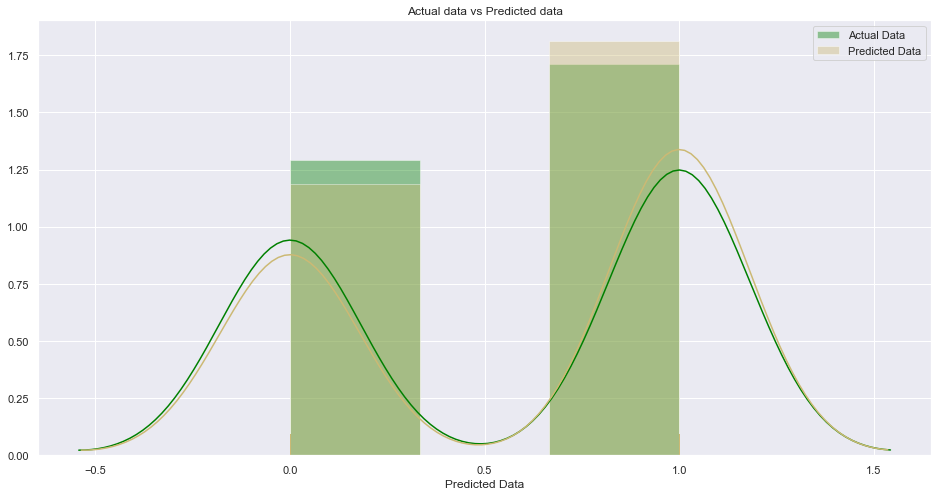

```python
sns.set_style('darkgrid')
plt.figure(figsize=(16,8))
sns.distplot(knn_df['Actual Data'],kde=True,label='Actual Data',color='green',rug=True)
sns.distplot(knn_df['Predicted Data'],kde=True,label='Predicted Data',color='y',rug=True)
plt.title('Actual data vs Predicted data')
plt.legend()
plt.show()
```

###### Confusion Matrix for KNN

```python
from sklearn.metrics import confusion_matrix
cmt_knn=confusion_matrix(y_test,knn_pred)
cmt_knn
```

```
array([[56, 33],
       [26, 92]], dtype=int64)
```

###### Accuracy Score for KNN Classifier

```python
from sklearn.metrics import accuracy_score
ac_knn=accuracy_score(knn_pred.round(),y_test,normalize=True)
ac_knn
```

```
0.714975845410628
```

###### Precision Score for KNN Classifier

```python
from sklearn.metrics import precision_score
pc_knn=precision_score(knn_pred.round(),y_test)
pc_knn
```

```
0.7796610169491526
```

###### Recall Score for KNN Classifier

```python
from sklearn.metrics import recall_score
rec_knn=recall_score(knn_pred.round(),y_test)
rec_knn
```

```
0.736
```

###### f1 score for KNN Classifier

```python
from sklearn.metrics import f1_score
f1_knn=f1_score(knn_pred.round(),y_test)
f1_knn
```

```
0.7572016460905351
```

### 3. Bernoulli Naive Bayes

```python
from sklearn.naive_bayes import BernoulliNB
bnb=BernoulliNB()
bnb.fit(x_train,y_train)
```

```
BernoulliNB(alpha=1.0, binarize=0.0, class_prior=None, fit_prior=True)
```

###### Predicting...

```python
bnb_pred=bnb.predict(x_test)
```

```python
bnb_df=pd.DataFrame({"Actual Data":y_test,"Predicted Data":bnb_pred})
```

```python
bnb_df
```

|  | Actual Data | Predicted Data |
| --- | --- | --- |
| 241 | 0 | 0 |
| 316 | 1 | 1 |
| 416 | 1 | 1 |
| 612 | 1 | 0 |
| 49 | 0 | 1 |
| 393 | 1 | 1 |
| 558 | 0 | 0 |
| 300 | 1 | 0 |
| 93 | 1 | 1 |
| 362 | 1 | 1 |
| 377 | 1 | 1 |
| 680 | 1 | 1 |
| 99 | 1 | 0 |
| 150 | 0 | 0 |
| 213 | 0 | 0 |
| 624 | 1 | 1 |
| 23 | 0 | 0 |
| 338 | 1 | 1 |
| 233 | 0 | 0 |
| 3 | 0 | 0 |
| 34 | 0 | 0 |
| 603 | 1 | 1 |
| 364 | 1 | 0 |
| 328 | 1 | 1 |
| 275 | 1 | 1 |
| 202 | 0 | 0 |
| 649 | 1 | 1 |
| 227 | 0 | 1 |
| 538 | 1 | 1 |
| 513 | 0 | 1 |
| ... | ... | ... |
| 379 | 1 | 1 |
| 159 | 0 | 0 |
| 37 | 0 | 0 |
| 381 | 1 | 1 |
| 631 | 1 | 0 |
| 526 | 1 | 1 |
| 242 | 0 | 1 |
| 331 | 1 | 1 |
| 47 | 0 | 0 |
| 195 | 0 | 0 |
| 487 | 1 | 1 |
| 44 | 0 | 0 |
| 297 | 1 | 1 |
| 305 | 1 | 1 |
| 544 | 1 | 0 |
| 589 | 0 | 0 |
| 623 | 1 | 1 |
| 79 | 1 | 1 |
| 539 | 1 | 0 |
| 132 | 0 | 0 |
| 566 | 0 | 0 |
| 402 | 1 | 1 |
| 441 | 1 | 1 |
| 400 | 1 | 1 |
| 67 | 0 | 0 |
| 229 | 0 | 1 |
| 342 | 1 | 1 |
| 193 | 0 | 0 |
| 685 | 1 | 1 |
| 597 | 0 | 0 |

207 rows × 2 columns

###### Actual Data Vs Predicted Data of Bernoulli Naive Bayes

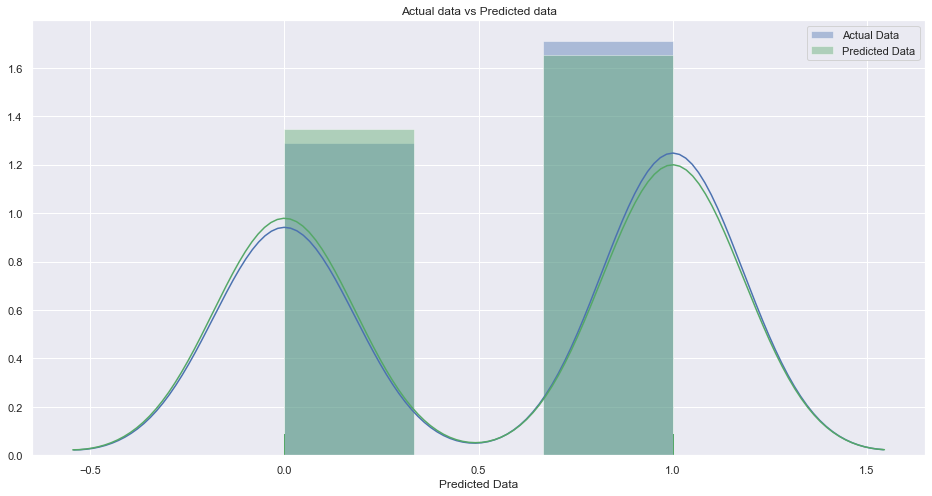

```python
sns.set_style('darkgrid')
plt.figure(figsize=(16,8))
sns.distplot(bnb_df['Actual Data'],kde=True,label='Actual Data',color='b',rug=True)
sns.distplot(bnb_df['Predicted Data'],kde=True,label='Predicted Data',color='g',rug=True)
plt.title('Actual data vs Predicted data')
plt.legend()
plt.show()
```

**Confusion Matrix for Bernoulli Naive Bayes**

```python
from sklearn.metrics import confusion_matrix
cmt_bnb=confusion_matrix(y_test,bnb_pred)
cmt_bnb
```

```
array([[68, 21],
       [25, 93]], dtype=int64)
```

**Accuracy Score for Bernoulli Naive Bayes**

```python
from sklearn.metrics import accuracy_score
ac_bnb=accuracy_score(bnb_pred.round(),y_test,normalize=True)
ac_bnb
```

```
0.7777777777777778
```

**Precision Score for Bernoulli Naive Bayes**

```python
from sklearn.metrics import precision_score
pc_bnb=precision_score(bnb_pred.round(),y_test)
pc_bnb
```

```
0.788135593220339
```

**Recall Score for Bernoulli Naive Bayes**

```python
from sklearn.metrics import recall_score
rec_bnb=recall_score(bnb_pred.round(),y_test)
rec_bnb
```

```
0.8157894736842105
```

**f1 Score for Bernoulli Naive Bayes**

```python
from sklearn.metrics import f1_score
f1_bnb=f1_score(bnb_pred.round(),y_test)
f1_bnb
```

```
0.8017241379310346
```

### 4. Support vector machine

```python
from sklearn.preprocessing import StandardScaler, scale
from sklearn.svm import LinearSVC
from sklearn.metrics import confusion_matrix
from sklearn.svm import SVC
svclassifier = SVC(kernel='linear')
svclassifier.fit(x_train, y_train)
```

```
SVC(C=1.0, break_ties=False, cache_size=200, class_weight=None, coef0=0.0,
    decision_function_shape='ovr', degree=3, gamma='scale', kernel='linear',
    max_iter=-1, probability=False, random_state=None, shrinking=True,
    tol=0.001, verbose=False)
```

```python
svc_pred = svclassifier.predict(x_test)
```

```python
svc_df=pd.DataFrame({"Actual Data":y_test,"Predicted Data":svc_pred})
```

```python
svc_df
```

|  | Actual Data | Predicted Data |
| --- | --- | --- |
| 241 | 0 | 0 |
| 316 | 1 | 1 |
| 416 | 1 | 1 |
| 612 | 1 | 1 |
| 49 | 0 | 1 |
| 393 | 1 | 1 |
| 558 | 0 | 0 |
| 300 | 1 | 1 |
| 93 | 1 | 0 |
| 362 | 1 | 1 |
| 377 | 1 | 1 |
| 680 | 1 | 1 |
| 99 | 1 | 0 |
| 150 | 0 | 0 |
| 213 | 0 | 0 |
| 624 | 1 | 1 |
| 23 | 0 | 0 |
| 338 | 1 | 1 |
| 233 | 0 | 0 |
| 3 | 0 | 0 |
| 34 | 0 | 0 |
| 603 | 1 | 1 |
| 364 | 1 | 1 |
| 328 | 1 | 1 |
| 275 | 1 | 1 |
| 202 | 0 | 0 |
| 649 | 1 | 1 |
| 227 | 0 | 1 |
| 538 | 1 | 0 |
| 513 | 0 | 0 |
| ... | ... | ... |
| 379 | 1 | 1 |
| 159 | 0 | 0 |
| 37 | 0 | 0 |
| 381 | 1 | 1 |
| 631 | 1 | 1 |
| 526 | 1 | 0 |
| 242 | 0 | 0 |
| 331 | 1 | 1 |
| 47 | 0 | 0 |
| 195 | 0 | 0 |
| 487 | 1 | 1 |
| 44 | 0 | 0 |
| 297 | 1 | 1 |
| 305 | 1 | 1 |
| 544 | 1 | 0 |
| 589 | 0 | 0 |
| 623 | 1 | 1 |
| 79 | 1 | 0 |
| 539 | 1 | 0 |
| 132 | 0 | 0 |
| 566 | 0 | 0 |
| 402 | 1 | 1 |
| 441 | 1 | 1 |
| 400 | 1 | 1 |
| 67 | 0 | 0 |
| 229 | 0 | 0 |
| 342 | 1 | 0 |
| 193 | 0 | 0 |
| 685 | 1 | 1 |
| 597 | 0 | 0 |

207 rows × 2 columns

**Actual Data Vs Predicted Data of Support Vector Classifier**

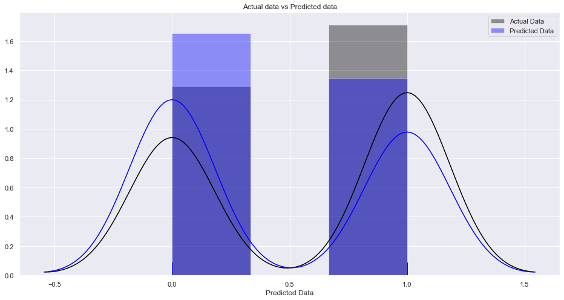

```python
sns.set_style('darkgrid')
plt.figure(figsize=(16,8))
sns.distplot(svc_df['Actual Data'],kde=True,label='Actual Data',color='black',rug=True)
sns.distplot(svc_df['Predicted Data'],kde=True,label='Predicted Data',color='blue',rug=True)
plt.title('Actual data vs Predicted data')
plt.legend()
plt.show()
```

**Confusion Matrix for Support Vector Classifier**

```python
from sklearn.metrics import confusion_matrix
cmt_svc=confusion_matrix(y_test,svc_pred)
cmt_svc
```

```
array([[84,  5],
       [30, 88]], dtype=int64)
```

**Accuracy Score for Support Vector Classifier**

```python
from sklearn.metrics import accuracy_score
ac_svc=accuracy_score(svc_pred.round(),y_test,normalize=True)
ac_svc
```

```
0.8309178743961353
```

**Precision Score for Support Vector Classifier**

```python
from sklearn.metrics import precision_score
pc_svc=precision_score(svc_pred.round(),y_test)
pc_svc
```

```
0.7457627118644068
```

**Recall Score for Support Vector Classifier**

```python
from sklearn.metrics import recall_score
rec_svc=recall_score(svc_pred.round(),y_test)
rec_svc
```

```
0.946236559139785
```

**f1 Score for Support Vector Classifier**

```python
from sklearn.metrics import f1_score
f1_svc=f1_score(svc_pred.round(),y_test)
f1_svc
```

```
0.8341232227488151
```

### 5. Decision Tree Classifier

```python
from sklearn.tree import DecisionTreeClassifier
dtree=DecisionTreeClassifier()
dtree.fit(x_train,y_train)
```

```
DecisionTreeClassifier(ccp_alpha=0.0, class_weight=None, criterion='gini',
                       max_depth=None, max_features=None, max_leaf_nodes=None,
                       min_impurity_decrease=0.0, min_impurity_split=None,
                       min_samples_leaf=1, min_samples_split=2,
                       min_weight_fraction_leaf=0.0, presort='deprecated',
                       random_state=None, splitter='best')
```

```python
dtree_pred=dtree.predict(x_test)
```

```python
dtree_df=pd.DataFrame({"Actual Data":y_test,"Predicted Data":dtree_pred})
dtree_df
```

|  | Actual Data | Predicted Data |
| --- | --- | --- |
| 241 | 0 | 1 |
| 316 | 1 | 1 |
| 416 | 1 | 1 |
| 612 | 1 | 1 |
| 49 | 0 | 1 |
| 393 | 1 | 1 |
| 558 | 0 | 0 |
| 300 | 1 | 1 |
| 93 | 1 | 0 |
| 362 | 1 | 1 |
| 377 | 1 | 0 |
| 680 | 1 | 1 |
| 99 | 1 | 0 |
| 150 | 0 | 1 |
| 213 | 0 | 0 |
| 624 | 1 | 1 |
| 23 | 0 | 0 |
| 338 | 1 | 1 |
| 233 | 0 | 0 |
| 3 | 0 | 0 |
| 34 | 0 | 0 |
| 603 | 1 | 1 |
| 364 | 1 | 1 |
| 328 | 1 | 1 |
| 275 | 1 | 1 |
| 202 | 0 | 0 |
| 649 | 1 | 1 |
| 227 | 0 | 1 |
| 538 | 1 | 1 |
| 513 | 0 | 0 |
| ... | ... | ... |
| 379 | 1 | 1 |
| 159 | 0 | 0 |
| 37 | 0 | 0 |
| 381 | 1 | 1 |
| 631 | 1 | 1 |
| 526 | 1 | 1 |
| 242 | 0 | 0 |
| 331 | 1 | 1 |
| 47 | 0 | 0 |
| 195 | 0 | 0 |
| 487 | 1 | 1 |
| 44 | 0 | 1 |
| 297 | 1 | 1 |
| 305 | 1 | 1 |
| 544 | 1 | 1 |
| 589 | 0 | 0 |
| 623 | 1 | 0 |
| 79 | 1 | 0 |
| 539 | 1 | 0 |
| 132 | 0 | 0 |
| 566 | 0 | 0 |
| 402 | 1 | 1 |
| 441 | 1 | 1 |
| 400 | 1 | 1 |
| 67 | 0 | 0 |
| 229 | 0 | 0 |
| 342 | 1 | 1 |
| 193 | 0 | 0 |
| 685 | 1 | 1 |
| 597 | 0 | 0 |

207 rows × 2 columns

**Actual Data Vs Predicted Data of Decision Tree Classifier**

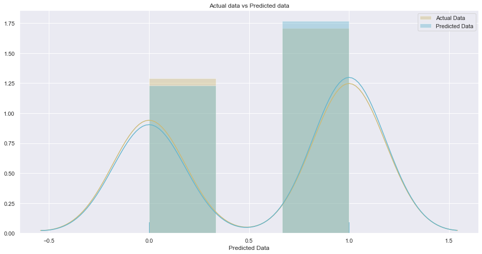

```python
sns.set_style('darkgrid')
plt.figure(figsize=(16,8))
sns.distplot(dtree_df['Actual Data'],kde=True,label='Actual Data',color='y',rug=True)
sns.distplot(dtree_df['Predicted Data'],kde=True,label='Predicted Data',color='c',rug=True)
plt.title('Actual data vs Predicted data')
plt.legend()
plt.show()
```

**Confusion Matrix for Decision Tree Classifier**

```python
from sklearn.metrics import confusion_matrix
cmt_dtree=confusion_matrix(y_test,dtree_pred)
cmt_dtree
```

```
array([[ 71,  18],
       [ 14, 104]], dtype=int64)
```

**Accuracy Score for Decision Tree Classifier**

```python
from sklearn.metrics import accuracy_score
ac_dtree=accuracy_score(dtree_pred.round(),y_test,normalize=True)
ac_dtree
```

```
0.8454106280193237
```

**Precison Score for Decision Tree Classifier**

```python
from sklearn.metrics import precision_score
pc_dtree=precision_score(dtree_pred.round(),y_test)
pc_dtree
```

```
0.8813559322033898
```

**Recall Score for Decision Tree Classifier**

```python
from sklearn.metrics import recall_score
rec_dtree=recall_score(dtree_pred.round(),y_test)
rec_dtree
```

```
0.8524590163934426
```

**f1 Score for Decision Tree Classifier**

```python
from sklearn.metrics import f1_score
f1_dtr=f1_score(dtree_pred.round(),y_test.round())
f1_dtr
```

```
0.8666666666666666
```

### 6. Random Forest Classifier

```python
from sklearn.ensemble import RandomForestClassifier
rfc = RandomForestClassifier().fit(x_train,y_train)
rfc
```

```
RandomForestClassifier(bootstrap=True, ccp_alpha=0.0, class_weight=None,
                       criterion='gini', max_depth=None, max_features='auto',
                       max_leaf_nodes=None, max_samples=None,
                       min_impurity_decrease=0.0, min_impurity_split=None,
                       min_samples_leaf=1, min_samples_split=2,
                       min_weight_fraction_leaf=0.0, n_estimators=100,
                       n_jobs=None, oob_score=False, random_state=None,
                       verbose=0, warm_start=False)
```

```python
rfc_predict = rfc.predict(x_test)
```

```python
rfc_df = pd.DataFrame({"Actual Data":y_test,"Predicted Data":rfc_predict})
rfc_df
```

|  | Actual Data | Predicted Data |
| --- | --- | --- |
| 241 | 0 | 0 |
| 316 | 1 | 1 |
| 416 | 1 | 1 |
| 612 | 1 | 1 |
| 49 | 0 | 1 |
| 393 | 1 | 1 |
| 558 | 0 | 0 |
| 300 | 1 | 1 |
| 93 | 1 | 1 |
| 362 | 1 | 1 |
| 377 | 1 | 1 |
| 680 | 1 | 1 |
| 99 | 1 | 0 |
| 150 | 0 | 0 |
| 213 | 0 | 0 |
| 624 | 1 | 1 |
| 23 | 0 | 0 |
| 338 | 1 | 1 |
| 233 | 0 | 0 |
| 3 | 0 | 0 |
| 34 | 0 | 0 |
| 603 | 1 | 1 |
| 364 | 1 | 1 |
| 328 | 1 | 1 |
| 275 | 1 | 1 |
| 202 | 0 | 0 |
| 649 | 1 | 1 |
| 227 | 0 | 1 |
| 538 | 1 | 0 |
| 513 | 0 | 1 |
| ... | ... | ... |
| 379 | 1 | 1 |
| 159 | 0 | 0 |
| 37 | 0 | 0 |
| 381 | 1 | 1 |
| 631 | 1 | 1 |
| 526 | 1 | 1 |
| 242 | 0 | 0 |
| 331 | 1 | 1 |
| 47 | 0 | 0 |
| 195 | 0 | 0 |
| 487 | 1 | 1 |
| 44 | 0 | 0 |
| 297 | 1 | 1 |
| 305 | 1 | 1 |
| 544 | 1 | 0 |
| 589 | 0 | 0 |
| 623 | 1 | 1 |
| 79 | 1 | 0 |
| 539 | 1 | 0 |
| 132 | 0 | 0 |
| 566 | 0 | 0 |
| 402 | 1 | 1 |
| 441 | 1 | 1 |
| 400 | 1 | 1 |
| 67 | 0 | 0 |
| 229 | 0 | 0 |
| 342 | 1 | 1 |
| 193 | 0 | 0 |
| 685 | 1 | 1 |
| 597 | 0 | 0 |

207 rows × 2 columns

###### Actual Data Vs Predicted Data of Random Forest Classifier

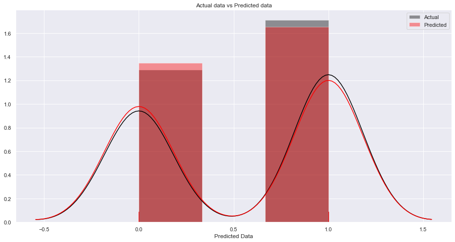

```python
sns.set_style('darkgrid')
plt.figure(figsize=(16,8))
sns.distplot(rfc_df['Actual Data'],kde=True,label='Actual',color='black',rug=True)
sns.distplot(rfc_df['Predicted Data'],kde=True,label='Predicted',color='red',rug=True)
plt.title('Actual data vs Predicted data')
plt.legend()
plt.show()
```

###### Confusion Matrix for Random Forest Classifier

```python
cmt_rtree=confusion_matrix(y_test,rfc_predict)
cmt_rtree
```

```
array([[ 76,  13],
       [ 17, 101]], dtype=int64)
```

###### Accuracy Score for Random Forest Classifier

```python
ac_rtree=accuracy_score(rfc_predict.round(),y_test,normalize=True)
ac_rtree
```

```
0.855072463768116
```

###### Precison Score for Random Forest Classifier

```python
pc_rtree=precision_score(rfc_predict.round(),y_test)
pc_rtree
```

```
0.8559322033898306
```

###### Recall Score for Random Forest Classifier

```python
rec_rtree=recall_score(rfc_predict.round(),y_test)
rec_rtree
```

```
0.8859649122807017
```

###### f1 score for Random Forest Classifier

```python
f1_rtree=f1_score(rfc_predict.round(),y_test.round())
f1_rtree
```

```
0.8706896551724138
```

### Evaluating the best model

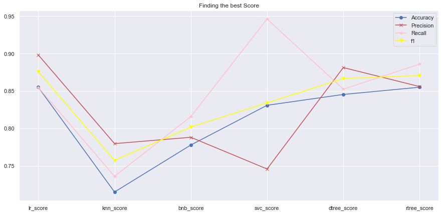

```python
acc_scores=[ac_lr,ac_knn,ac_bnb,ac_svc,ac_dtree,ac_rtree]
pc_scores =[pc_lr,pc_knn,pc_bnb,pc_svc,pc_dtree,pc_rtree]
rec_scores=[rec_lr,rec_knn,rec_bnb,rec_svc,rec_dtree,rec_rtree]
f1_scores =[f1_lr,f1_knn,f1_bnb,f1_svc,f1_dtr,f1_rtree]
algs=['lr_score','knn_score','bnb_score','svc_score','dtree_score','rtree_score']
plt.figure(figsize=(15,7))
plt.plot(algs,acc_scores,marker='o',color='b',label = 'Accuracy')
plt.plot(algs,pc_scores,marker='x',color='r',label= "Precision")
plt.plot(rec_scores,marker='*',color='pink',label="Recall")
plt.plot(f1_scores,marker='v',color='yellow',label="f1")
plt.title('Finding the best Score')
plt.legend()
plt.grid(True)
```

### From the above figure, Support vector Classifier is not a good fit because there is a high difference between precision and recall. Hence, we can conclude that the Logistic Regression is the best fit as the Precision is high as well as the accuracy score when compared to the other models.